# 徐乔依

Joyce

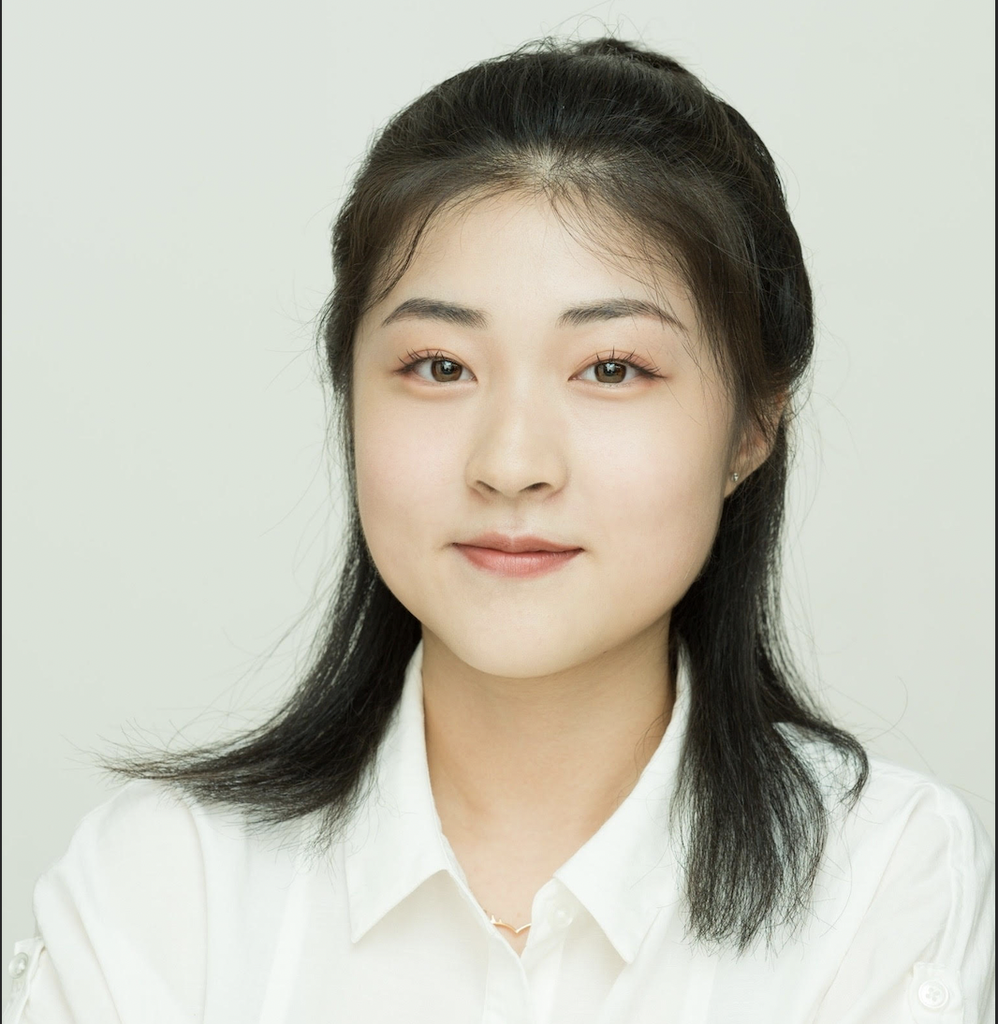

Qiaoyi Xu，照片来自原个人主页

公共卫生连接人群健康与数据证据。我希望运用流行病学和数据分析知识，为改善健康作出贡献。

下载个人主页 PDF [LinkedIn](https://www.linkedin.com/in/qiaoyi-xu-99b8091b9/)

## 关于我

我叫 **Qiaoyi Xu（Joyce）**，家乡是北京。目前在北京大学攻读流行病学与卫生统计学博士学位，此前在哥伦比亚大学和马萨诸塞大学阿默斯特分校学习公共卫生、流行病学与数学。我的职业目标是将所学用于健康领域，帮助人们改善健康。

查看完整简历 · 下载简历 PDF

## 教育背景

**北京大学 · Beijing, China**  
2026 年 9 月至预计 2030 年 7 月，Doctor of Philosophy in Epidemiology and Biostatistics。

**哥伦比亚大学 · New York, NY**  
2021 年 9 月至 2023 年 5 月，Master of Public Health in Epidemiolog，Certificate in Applied Biostatistics；GPA：3.93。

**马萨诸塞大学阿默斯特分校 · Amherst, MA**  
2018 年 9 月至 2021 年 5 月，Bachelor of Science in Public Health Sciences and Mathematics。  
双专业；GPA：3.8。

## 工作与实习经历

- **Pharmaron Clinical · Biostatistician**（2023 年 7 月至 2026 年 8 月）：参与 I/II 期临床试验、生物等效性研究、研究者发起试验及 FDA IND 申请支持分析；编写 SAP、TLF 模板等统计文件，审核研究方案与相关交付文件。
- **Pfizer · 流行病学研究助理**（2022 年 6–8 月，纽约）：支持莱姆病疫苗相关流行病学研究，开展加拿大蜱监测系统文献综述，使用 SAS 分析数据并汇报结果。
- **Frost & Sullivan · 咨询分析实习生**（2021 年 12 月至 2022 年 2 月，上海）：参与资料收集、市场分析展示及专家访谈纪要整理。
- **National Center for Medical Service Administration · 数据分析实习**（2020 年 7–9 月，北京）：收集核酸检测数据、开展分析并撰写日报。
- **中国疾病预防控制中心 · 数据分析与健康传播实习**（2019 年 6–8 月，北京）：收集和分析环境健康相关数据，参与环境健康科普活动。

## 数据分析作品

**纽约州 NOAA 气象数据探索**  
该作品使用 R、Plotly 和 flexdashboard，展示散点图、柱状图与箱线图。它体现了从数据整理到交互式可视化的分析实践。

查看交互图表 · 查看仪表板 · [数据集说明](https://p8105.com/dataset_noaa.html)

## 技能与兴趣

**分析工具：** R、SAS、MySQL、Excel。  
**语言：** 中文、英文。  
**个人兴趣：** 舞蹈、冲浪、百老汇音乐剧；我的猫叫 Erer。

## 联系与资料

[GitHub](https://github.com/joycexu2000-web) · [LinkedIn](https://www.linkedin.com/in/qiaoyi-xu-99b8091b9/) · [原个人主页](https://qiaoyixu.github.io/)

**Phone number：** +86 15711312382  
**Email：** qiaoyixu2000@gmail.com  
**Address：** Beijing, China